# Global Plastic Waste

Yifei Liu

5/27/2019

load data

After viewing the dataset, I have a couple of questions in mind.

1. Which country produces the most plastic waste? I imagine it related two at least two factors, income level, and population. Generally I hypothesis the richer and more people you have, the more plastic waste your produce.

Base on this question, I think I should first plot plastic waste per person against GDP per capita, see the relationship, may need log transfer, and add population as point size.

2. What’s the relationship between plastic waste mismanaged, (as someone grows up in China, and see the pictures about little girls play with disposable needles), I suspect China will be on top of the list in terms of plastic waste mismanagement. And strong environmental regulation may also have an effect on this case. We can put mismanaged plastic waste per person and total mismanaged plastic waste on the map and see which country responsible for most mismanage plastic waste.

Base on this question, I will take a similar step as last one, but maybe add few steps such as calculate individual country mismanagement waste/sum (mismanaged waste) see which country have the highest share.

3. As a Finance major student/person, I remember China impose a plastic waste ban. ABC, CNBC, etc several media outlet say developed countries such as the U.S., Australia may face “recycle crisis”, PS: I always believe media overexerted circumstance. I will see if I use UN Comtrade to trace plastic waste back to their origin countries will this make the previous conclusion, without trade adjustment, any different. Also, I know Sweden burn more plastic waste than it produces, so it has to import waste, this may also be a factor.

Get trade data from Comtrade r package, and add back to its origin.

4. I lack expertise in this area, which means I believe there are a lot of important information I may not know I even needed (areas of unknown unknown)

### Income level and plastic waste relationship

let take a look at waste_vs_gdp.csv file, see which country generate the most plastic waste.

In these three dataset, I find global plastic waste data in 2010. There are still some mising value in 2010, we can do some mutation.

First, I assume there exhit a relationship between plastic waste per capita and gdp per capita. Plot these two variable on a chart, see what happen.

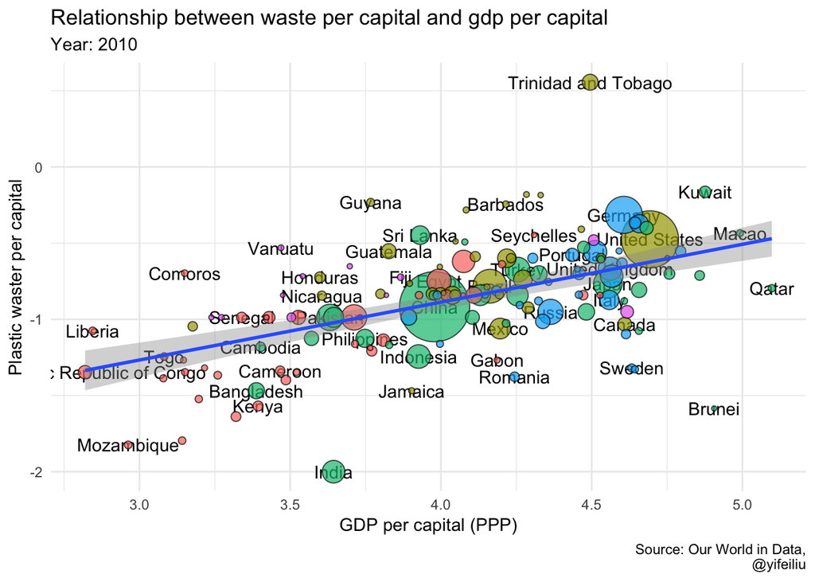

This figuare give a us some clear inforamtion about the relationship between gdp per capita and plastic waste per capita.

we can see a clear upward trend in this plastic waste data, so I have a rough assumption, as people inside a country become richer and richer, people generate generate more waste. We can try to transfer these data by fitting a linear regression and mins their current data, see base their income level, which country do a beter job at lower plastic waste per capital.

The are also some news about countries such as China, Thiland and India start to ban trash import. I think we can try to extract these information from UN trade pacakge and put these trash to their original country for more accurate analysis.

Let’s take a look during 2010 how many plastic waste has China imported.

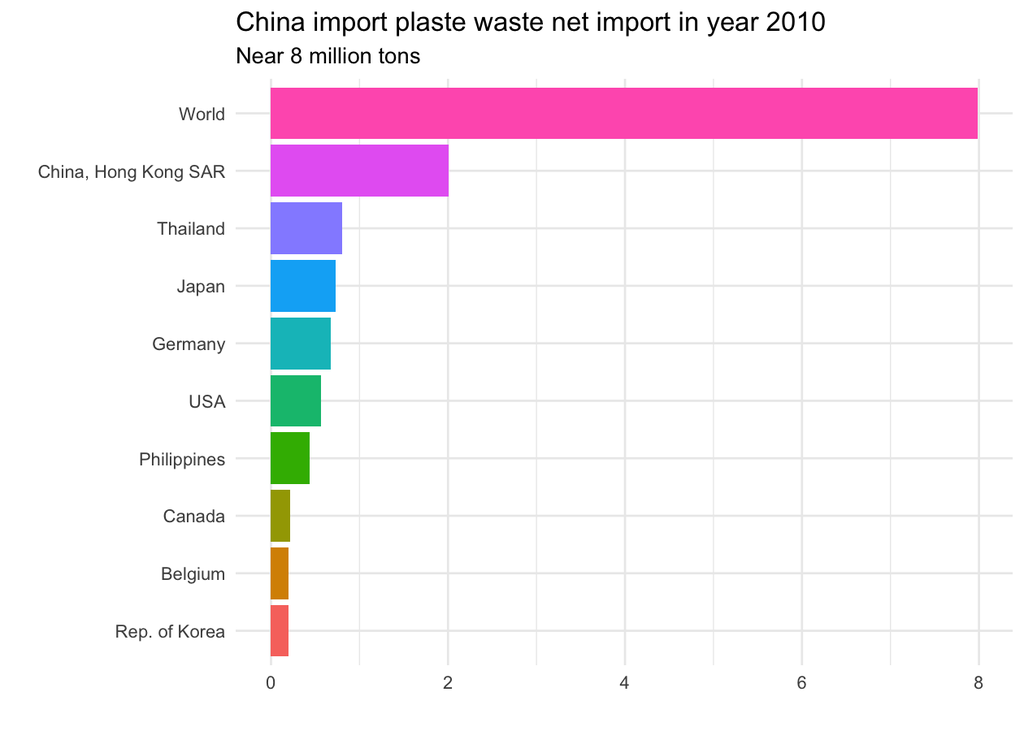

Let’s takea a look at how many plastic waste produce in China

```
## [1] "13.5%"
```

China import about 13.5% of plastic waste. If we want to analyze which country produce the most plastic waste and do the most environment damage, we can adjust all these import/export back.

PS: I just download these data from [US Comtrade Database](https://comtrade.un.org/data/), since it prohibt I donwload trade item cross all these import/export country

Now we have global plastic waste trade data, we can join this dataset to original data and see what impact does trade have on global plastic waste amount.

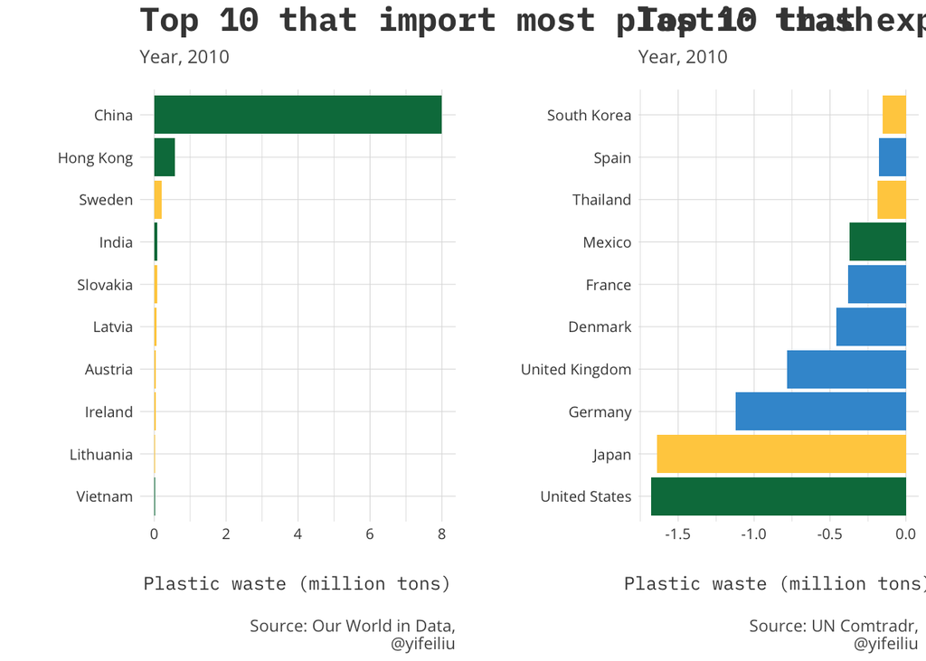

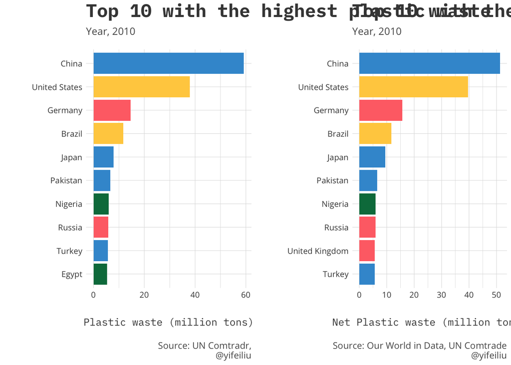

we can see after adjust for import/export, rich country show more plastic waste than their original show. This could be a more accurate represenation about how many plasic waste a country actuall generate. And this will be give us a better understanding about impact of current China trash ban.

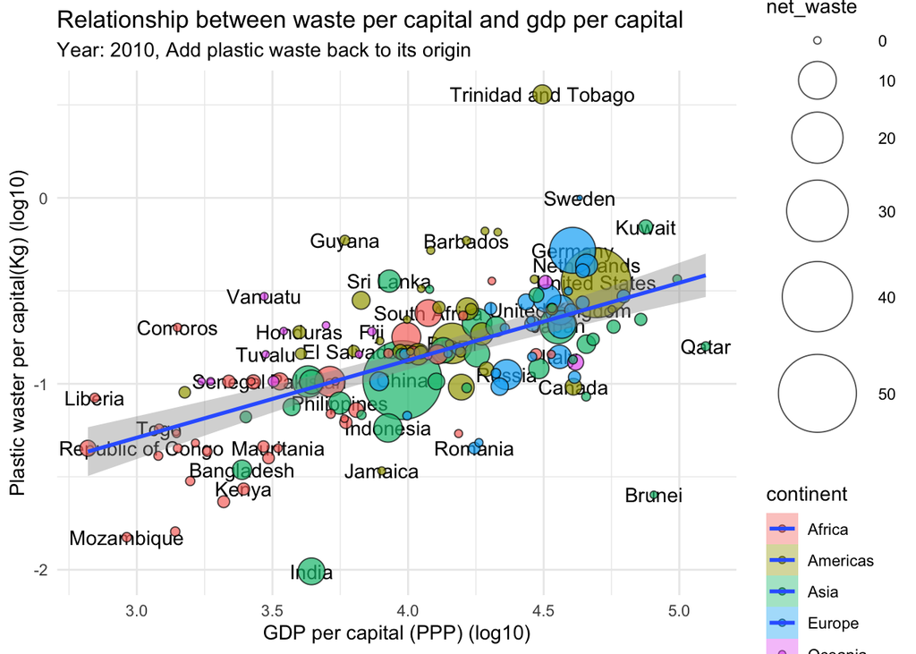

```
## # A tibble: 4 x 6
##   term        estimate std.error statistic  p.value adjusted
##   <chr>          <dbl>     <dbl>     <dbl>    <dbl> <chr>
## 1 (Intercept)   -2.41     0.204     -11.8  6.62e-23 No
## 2 gdp_per_log    0.380    0.0503      7.54 4.49e-12 No
## 3 (Intercept)   -2.54     0.205     -12.4  2.03e-24 Yes
## 4 gdp_per_log    0.416    0.0503      8.27 8.24e-14 Yes
```

```
## # A tibble: 2 x 5
##   r.squared adj.r.squared    df   AIC adjusted
##       <dbl>         <dbl> <int> <dbl> <chr>
## 1     0.280         0.276     2  75.8 No
## 2     0.324         0.319     2  71.9 Yes
```

We can compare this trade adjusted waste per capita data with previous waste per capital data, we can say the linear relationship become more clear, adjusted R value increase from 0.28 to 0.32. And (intercept) and gdp_per_log term also changed. The upward trend be more clear this time.

Now we can see which country use more plastic waste per capita relative to their gdp per capita.

```
## # A tibble: 280 x 10
##    gdp_per_log net_waste_per_l… Entity continent net_waste population Code
##          <dbl>            <dbl> <chr>  <chr>         <dbl>      <dbl> <chr>
##  1        4.50            0.557 Trini… Americas     1.76e9    1341465 TTO
##  2        3.77           -0.228 Guyana Americas     1.63e8     754493 GUY
##  3        4.28           -0.179 Antig… Americas     2.15e7      88710 ATG
##  4        3.47           -0.530 Vanua… Oceania      2.58e7     239651 VUT
##  5        4.08           -0.282 Saint… Americas     3.32e7     174267 LCA
##  6        4.22           -0.230 Barba… Americas     5.87e7     273331 BRB
##  7        4.33           -0.184 Saint… Americas     1.25e7      52402 KNA
##  8        3.15           -0.697 Comor… Africa       5.39e7     734750 COM
##  9        3.93           -0.448 Sri L… Asia         2.72e9   20859949 LKA
## 10        3.83           -0.551 Guate… Americas     1.48e9   14388929 GTM
## # … with 270 more rows, and 3 more variables: resid <dbl>,
## #   waste_extra <dbl>, per_person <dbl>
```

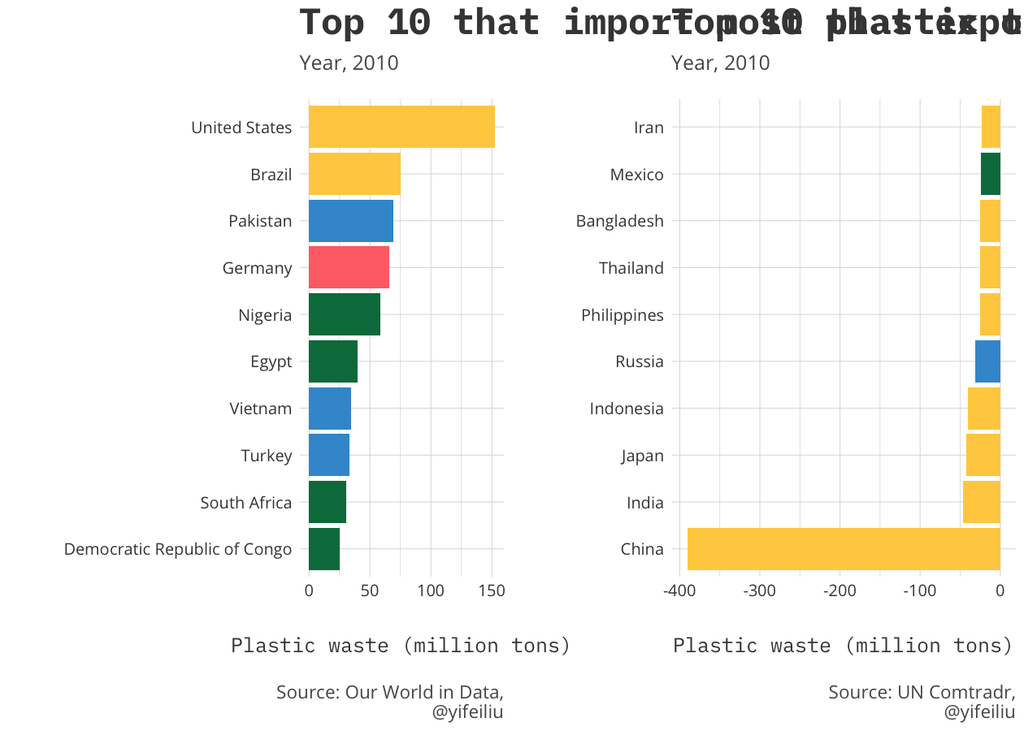

We can see countries such as United States, Brazil, Pakistan and Germany produce much more plastic waste relative to their income level. And on per capital base, Countries such as Trinidad, Gyyana and Antigua and Barbuda produce more plastic waste.

Now let’s put plastic waste and plastic waste extra on a map

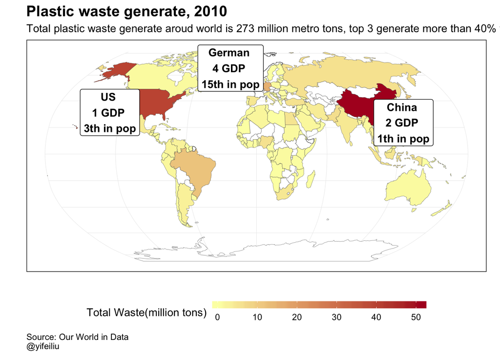

As expected, richer countries with more population produce more plastic waste.

Let’s take a look at per capita plastic waste, does rich country generate have more net plastic waste

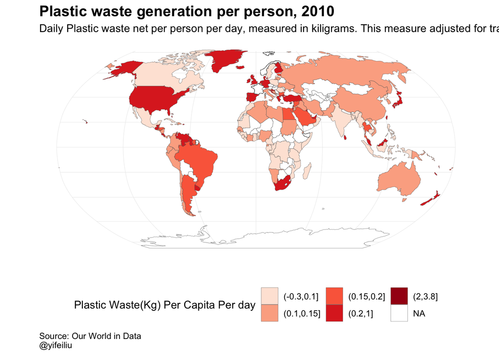

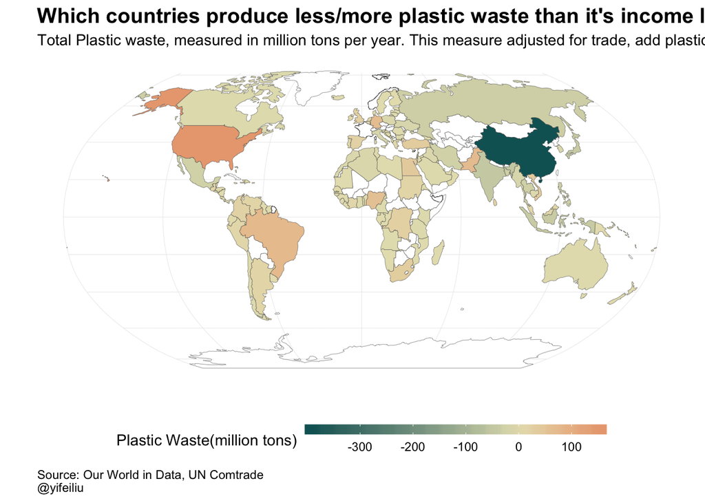

Now after adjusted plastic waste trade, we can say which country produce more trash than it’s income level and which country produce less.

Now I want to take a look at mis manage plastic waste. See Which country response of most mismanaged plastic waste. Take a look at does low income country have highest mismanaged plastic waste and put these on map.

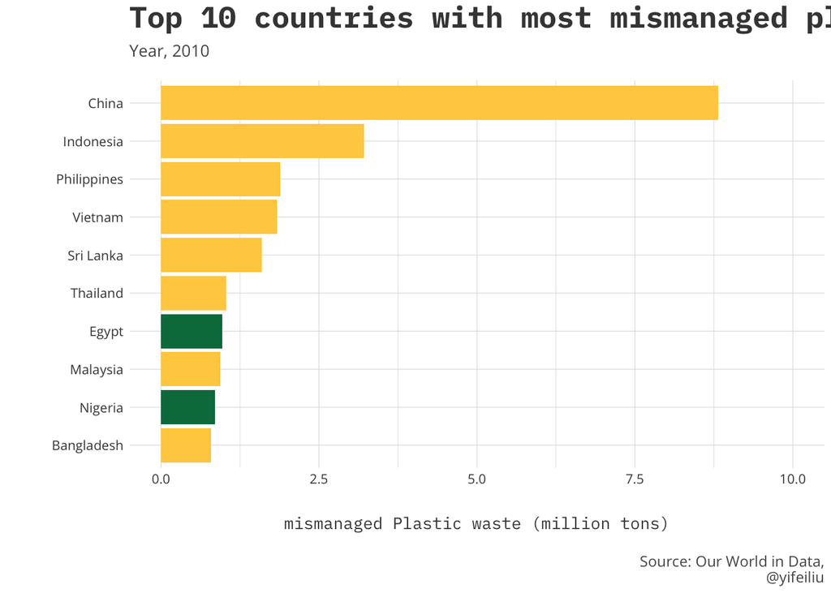

```
## # A tibble: 280 x 22
##    Entity Code  per_capita_plas… gdp_per population per_capita_mism…
##    <chr>  <chr>            <dbl>   <dbl>      <dbl>            <dbl>
##  1 China  CHN              0.121   9526. 1341335152            0.092
##  2 Indon… IDN              0.057   8433.  239870937            0.047
##  3 Phili… PHL              0.075   5597.   93260798            0.062
##  4 Vietn… VNM              0.103   4408.   87848445            0.09
##  5 Sri L… LKA              0.357   8530.   20859949            0.299
##  6 Thail… THA              0.144  13487.   69122234            0.108
##  7 Egypt  EGY              0.178   9857.   81121077            0.122
##  8 Malay… MYS              0.198  21107.   28401017            0.112
##  9 Niger… NGA              0.103   5150.  158423182            0.085
## 10 Bangl… BGD              0.034   2443.  148692131            0.03
## # … with 270 more rows, and 16 more variables: mismanaged_plastic <dbl>,
## #   coastal_pop <dbl>, iso2 <chr>, continent <chr>, reporter <chr>,
## #   partner <chr>, partner_iso <chr>, net_import <dbl>, total_waste <dbl>,
## #   waste_per_log <dbl>, gdp_per_log <dbl>, total_gdp <dbl>,
## #   waste_quant <fct>, net_waste <dbl>, net_waste_per_log <dbl>,
## #   mis_pct <dbl>
```

```
## # A tibble: 105 x 22
##    Entity Code  per_capita_plas… gdp_per population per_capita_mism…
##    <chr>  <chr>            <dbl>   <dbl>      <dbl>            <dbl>
##  1 Afgha… AFG                 NA   1614.   31411743               NA
##  2 <NA>   ALA                 NA     NA          NA               NA
##  3 Ameri… ASM                 NA     NA       68420               NA
##  4 Andor… AND                 NA     NA       84864               NA
##  5 <NA>   ATA                 NA     NA          NA               NA
##  6 Armen… ARM                 NA   6703.    3092072               NA
##  7 Austr… AUT                 NA  43336.    8393644               NA
##  8 <NA>   <NA>                NA     NA          NA               NA
##  9 Azerb… AZE                 NA  15950.    9187783               NA
## 10 <NA>   <NA>                NA     NA          NA               NA
## # … with 95 more rows, and 16 more variables: mismanaged_plastic <dbl>,
## #   coastal_pop <dbl>, iso2 <chr>, continent <chr>, reporter <chr>,
## #   partner <chr>, partner_iso <chr>, net_import <dbl>, total_waste <dbl>,
## #   waste_per_log <dbl>, gdp_per_log <dbl>, total_gdp <dbl>,
## #   waste_quant <fct>, net_waste <dbl>, net_waste_per_log <dbl>,
## #   mismanage_pct <dbl>
```

```
## [1] 31.84329
```

```
## # A tibble: 280 x 21
##    Entity Code  per_capita_plas… gdp_per population per_capita_mism…
##    <chr>  <chr>            <dbl>   <dbl>      <dbl>            <dbl>
##  1 China  CHN              0.121   9526. 1341335152            0.092
##  2 Indon… IDN              0.057   8433.  239870937            0.047
##  3 Phili… PHL              0.075   5597.   93260798            0.062
##  4 Vietn… VNM              0.103   4408.   87848445            0.09
##  5 Sri L… LKA              0.357   8530.   20859949            0.299
##  6 Thail… THA              0.144  13487.   69122234            0.108
##  7 Egypt  EGY              0.178   9857.   81121077            0.122
##  8 Malay… MYS              0.198  21107.   28401017            0.112
##  9 Niger… NGA              0.103   5150.  158423182            0.085
## 10 Bangl… BGD              0.034   2443.  148692131            0.03
## # … with 270 more rows, and 15 more variables: mismanaged_plastic <dbl>,
## #   coastal_pop <dbl>, iso2 <chr>, continent <chr>, reporter <chr>,
## #   partner <chr>, partner_iso <chr>, net_import <dbl>, total_waste <dbl>,
## #   waste_per_log <dbl>, gdp_per_log <dbl>, total_gdp <dbl>,
## #   waste_quant <fct>, net_waste <dbl>, net_waste_per_log <dbl>
```

And if I use (Per capita mismanaged plastic waste (kg per day)) * population * 365 / sum(all indivual numbs), China share jump to 41.7%, I think the reason for such disparity is due to missing data, probabily there are missing valuein per_capita_missmaged or population cause such different. After checking the report on Ourworldindata I think I will use 27.8% method.

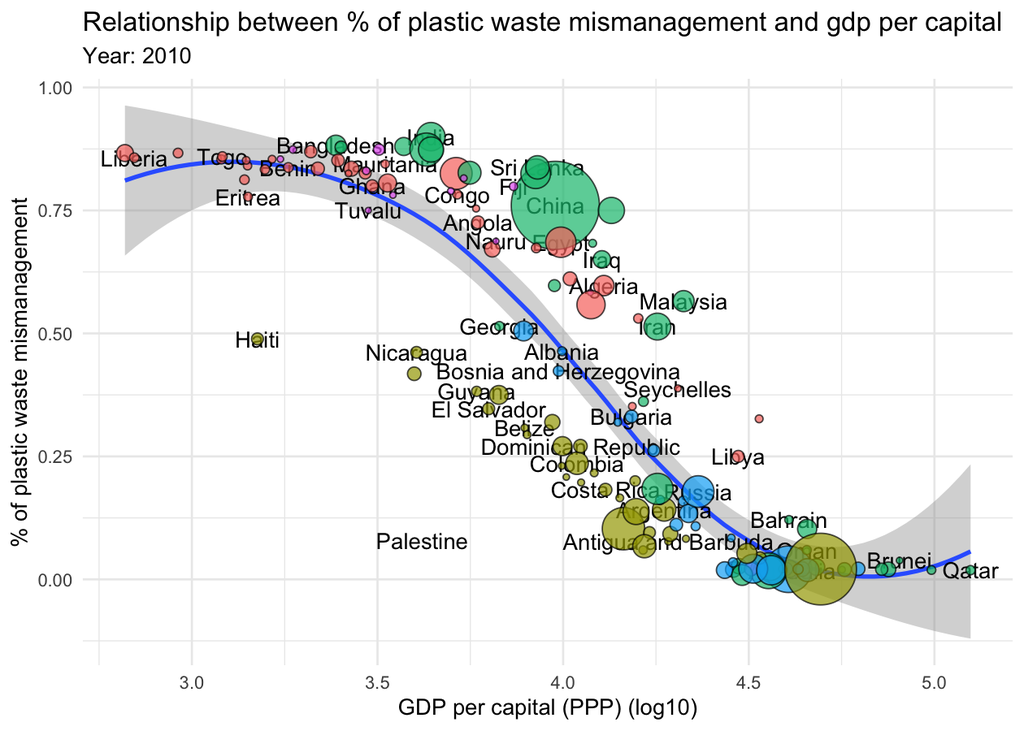

we can see the percentage of waste that are mismanaged are lower in high income countries and higher in low income country, and relationship are not linear.

Let’s take a look at pre trade adjusted mismanaged plastic waste distribution globally.

[figure not shown]

And ths is pre adjusted trade data waste, we can now adjusted for trade. I assume, after transfer plastic waste back, countries will use their original % of plastic waste mismanagedment method to deal with this trade plastic waste.

```
## [1] "17.6%"
```

we can see if develope country don’t export plastic trash to developing countries, instead landfill domestically, it will reduce total missmanged plastic waste by around 17.6% (if all my assumption were correct.)

Data analytical concludion:

1. Global plastic waste production reach 270 million tons, China, U.S., and Germany are the primary produce count more than 40% of global plastic waste. (didn’t expected germany be this high, since Euorpean take so much about envirornment)

2 Plastic waste per person have a linear relationship with gdp per capita, after log-log transformation.

3. China import around 8 million tons plastic waste, count for 13.5% of China total plasic waste.
4. After adjusted for plastic waste trade, the trend become more clear between income level and plastic waste per person. (Adjusted R increase, trned goes up)

Data analytical problem conclusion:

1. Missing data will screw you in a way you least expected. Be very careful will dealing with missing data, it could screw all you analysis and conclusion.
2. Put more attention to observation, in this case, some observation are not like others they are not countries but aggregate level such as world, OECD, asian, north amerca. It could also screw you analysis.